# Lab7

Irlanda Ayon-Moreno

4/13/2018

# Lab 7: Simple Functions and Conditionals

Gaston Sanchez

### Learning Objectives

> - Learn how to write simple functions
> - Get into the habit of writing simple functions
> - Get into the habit of documenting functions
> - Make sure your functions work
> - Use conditionals if-then-else

## Introduction

In this lab you will practice writing simple functions, and some basic examples to make sure that the functions work as expected. Later in the course we will see how to write assertions (i.e. tests) for your functions in a more formal way.

In addition to writing the functions, you should also practice documenting your functions. Writing this type of documentation should become second nature. To do this, include roxygen comments such as:

- `#' @title Name of your function`
- `#' @description What the function does`
- `#' @param x input(s) of your function`
- `#' @return output of your function`

### Before you start …

By setting the global option `error = TRUE` you avoid the knitting process to be stopped in case a code chunk generates an error.

Since you will be writing a couple of functions with `stop()` statements, it is essential that you set up `error = TRUE`, otherwise `"knitr"` will stop knitting your `Rmd` file if it encounters an error.

### Toy Example

Here’s an example of how to write a function with its documentation:

```r
#' @title area of rectangle
#' @description calculates the area of a rectangle
#' @param len length of the rectangle (numeric)
#' @param wid width of the rectangle (numeric)
#' @return computed area
rect_area <- function(len = 1, wid = 1) {
  if (len < 0) {
    stop("len must be positive")
  }
  if (wid < 0) {
    stop("wid must be positive")
  }
  area <- len * wid
  return(area)
}
```

Some tests:

```r
# default
rect_area()
```

```
## [1] 1
```

```r
# len=2, wid=3
rect_area(len = 2, wid = 3)
```

```
## [1] 6
```

```r
# bad len
rect_area(len = -2, wid = 3)
```

```
## Error in rect_area(len = -2, wid = 3): len must be positive
```

## Simple Math Functions

Consider the following mathematical functions:

- *f*(*x*)=*x*<sup>2</sup>
- *g*(*x*)=2*x* + 5

Write two functions `f()` and `g()` based on the previous equations. Don’t forget to include roxygen comments to document your function!

```r
# function f()
#' @title squared
#' @description multiplies a number times itself
#' @param x (numeric)
#' @return computed product
f <- function(x) {
  x^2
}
```

```r
# function g()
#' @title equation
#' @description multiplies a number times 2 and adds 5 to the product
#' @param x (numeric)
#' @return computed answer
g <- function(x) {
  2 * x + 5
}
```

Test your functions with:

```r
f(2)     # 4
```

```
## [1] 4
```

```r
f(-5)    # 25
```

```
## [1] 25
```

```r
g(0)     # 5
```

```
## [1] 5
```

```r
g(-5/2)  # 0
```

```
## [1] 0
```

Use your functions `f()` and `g()` to create the following composite functions:

- `fog()` for the composite function: *f* ∘ *g*(*x*)
- `gof()` for the composite function: *g* ∘ *f*(*x*)

```r
# function fog()
#' @title F of G
#' @description the function g is an input to the function f
#' @param x (numeric)
#' @return computed answer
fog <- function(x) {f(g(x))}
```

```r
# function gof()
#' @title G of F
#' @description the function f is an input to the function g
#' @param x (numeric)
#' @return computed answer
gof <- function(x) {g(f(x))}
```

Test your composite functions with:

```r
fog(2)     # 81
```

```
## [1] 81
```

```r
fog(-5)    # 25
```

```
## [1] 25
```

```r
gof(0)     # 5
```

```
## [1] 5
```

```r
gof(-5/2)  # 17.5
```

```
## [1] 17.5
```

## Pythagoras

The pythagoras formula is used to compute the length of the hypotenuse, *c*, of a right triangle with legs of length *a* and *b*.

Write a function `pythagoras()` that takes two arguments `a` and `b`, and returns the length of the hypotenuse. Don’t forget to include roxygen comments to document your function!

```r
# pythagoras() function
#' @title pythagoras formula
#' @description computes the length of the hypotenuse
#' @param a length of one leg (numeric)
#' @param b length of second leg (numeric)
#' @return length of the hypotenuse
pythagoras <- function(a, b) {sqrt(a^2 + b^2)}

# pythagoras ver2
pythagoras <- function(a, b = a) {
  sqrt(a^2 + b^2)
}
```

Test your `pythagoras()` with two leg values: `pythagoras(3, 4)`

```r
# test
pythagoras(3, 4)
```

```
## [1] 5
```

Modify your function `pythagoras()` so that argument `b` takes the same value of argument `a`. Test it with just one leg value: `pythagoras(5)`

```r
# test
pythagoras(5)
```

```
## [1] 7.071068
```

## Area of a circle

Consider a circle with `radius = 2`. The area of this circle can be computed in R as:

```r
# area of circle with radius 2
r <- 2
area <- pi * r^2
area
```

```
## [1] 12.56637
```

Write a function `circle_area()` that calculates the area of a circle. This function must take one argument `radius`. Give `radius` a default value of 1. Don’t forget to include roxygen comments to document your function!

```r
#' @title area of a circle
#' @description calculates the area of a circle
#' @param radius radius of a circle (numeric)
#' @return computed area
circle_area <- function(radius = 1) {
  if (radius < 0) {
    stop("radius must be positive")
  }
  area <- pi * radius^2
  return(area)
}
```

```r
# default (radius 1)
circle_area()
```

```
## [1] 3.141593
```

```r
# radius 3
circle_area(radius = 3)
```

```
## [1] 28.27433
```

Modify your `circle_area()` function in order to include a `stop()` statement. If `radius` is negative, then the function should stop with a message like: `"radius cannot be negative"`.

Test your modified `circle_area()` with `radius = -2`; the function should return a stop message:

```r
# bad radius
circle_area(radius = -2)
```

```
## Error in circle_area(radius = -2): radius must be positive
```

## Area of a cylinder

For a given cylinder of radius *r* and height *h* the area *A* is:

*A* = 2*π**r**h* + 2*π**r*<sup>2</sup>

For example. Say you have a cylinder with radius = 2, and height = 3.

```r
# cylinder variables
r = 2  # radius
h = 3  # height

# area of cylinder
2 * pi * r * h + 2 * pi * r^2
```

```
## [1] 62.83185
```

Notice that the formula of the area of a cylinder includes the area of a circle: *π**r*<sup>2</sup>. Write a function `cylinder_area()`, that calls `circle_area()`, to compute the area of a cylinder.

This function must take two arguments: `radius` and `height`. Give both arguments a default value of 1. In addition, the function should stop if any of `radius` or `height` are negative.

```r
#' @title area of a cylinder
#' @description calculates the area of a cylinder
#' @param radius radius of a cylinder (numeric)
#' @param height height of a cylinder (numeric)
#' @return computed area
cylinder_area <- function(radius = 1, height = 1) {
  if (radius < 0) {
    stop("radius must be positive")
  }
  if (height < 0) {
    stop("height must be positive")
  }
  area <- 2 * pi * radius * height + 2 * pi * radius^2
  return(area)
}
```

For instance:

```r
# default (radius 1, height 1)
cylinder_area()
```

```
## [1] 12.56637
```

```r
# radius 2, height 3
cylinder_area(radius = 2, height = 3)
```

```
## [1] 62.83185
```

These should return an error message:

```r
# bad radius
cylinder_area(radius = -2, height = 1)
```

```
## Error in cylinder_area(radius = -2, height = 1): radius must be positive
```

```r
# bad height
cylinder_area(radius = 2, height = -1)
```

```
## Error in cylinder_area(radius = 2, height = -1): height must be positive
```

```r
# bad radius and height
cylinder_area(radius = -2, height = -1)
```

```
## Error in cylinder_area(radius = -2, height = -1): radius must be positive
```

## Volume of a cylinder

For a given cylinder of radius *r* and height *h* the volume *V* is:

*V* = *π**r*<sup>2</sup>*h*

Write a function `cylinder_volume()`, that calls `circle_area()`, to compute the volume of a cylinder. This function must take two arguments: `radius` and `height`. Give both arguments a default value of 1.

```r
#' @title volume of a cylinder
#' @description calculates the volume of a cylinder
#' @param radius radius of a cylinder (numeric)
#' @param height height of a cylinder (numeric)
#' @return computed volume
cylinder_volume <- function(radius = 1, height = 1) {
  circle_area(radius) * height
}
```

For example:

```r
# default (radius 1, height 1)
cylinder_volume()
```

```
## [1] 3.141593
```

```r
cylinder_volume(radius = 3, height = 10)
```

```
## [1] 282.7433
```

```r
cylinder_volume(height = 10, radius = 3)
```

```
## [1] 282.7433
```

## Unit Conversion Formulas

The following exercises involve writing simple functions to convert from one type of unit to other.

### Miles to Kilometers

Write a function `miles2kms()` that converts miles into kilometers: 1 mile is equal to 1.6 kilometers. Give the argument a default value of 1.

```r
#' @title miles converter
#' @description converts miles into kilometers
#' @param miles miles to convert (numeric)
#' @return kilometers
miles2kms <- function(miles = 1) {miles * 1.6}
```

Use `miles2kms()` to obtain mile conversions, in order to create a table (i.e. data frame). The first ten rows range from 1 to 10 miles, and then from 10 to 100 in 10 mile steps. The second column corresponds to kms.

```r
data.frame(miles = c(1:9, seq(10, 100, 10)),
           kms = miles2kms(miles = c(1:9, seq(10, 100, 10))))
```

```
##    miles   kms
## 1      1   1.6
## 2      2   3.2
## 3      3   4.8
## 4      4   6.4
## 5      5   8.0
## 6      6   9.6
## 7      7  11.2
## 8      8  12.8
## 9      9  14.4
## 10    10  16.0
## 11    20  32.0
## 12    30  48.0
## 13    40  64.0
## 14    50  80.0
## 15    60  96.0
## 16    70 112.0
## 17    80 128.0
## 18    90 144.0
## 19   100 160.0
```

### Gallons to Liters, and viceversa

Write a function `gallon2liters()` that converts gallons to liters: 1 gallon is equal to 3.78541 liters:

```r
#' @title gallon converter
#' @description converts gallons to liters
#' @param gallons number of gallons (numeric)
#' @return liters
gallons2liters <- function(gallons) {
  gallons * 3.78541
}
```

Use `gallon2liters()` to make an inverse function `liters2gallons()`.

```r
#' @title liters converter
#' @description converts liters to gallons
#' @param liters number of liters (numeric)
#' @return gallons
liters2gallons <- function(liters = 1) {
  1 / gallons2liters(liters)
}
```

Use `liters2gallons()` to obtain liter conversions, in order to create a table (i.e. data frame). The first ten rows range from 1 to 10 liters, and then from 10 to 100 in 10 liter steps. The second column corresponds to gallons.

```r
data.frame(liters = c(1:9, seq(10, 100, 10)),
           gallons = liters2gallons(c(1:9, seq(10, 100, 10)))
           )
```

```
##    liters     gallons
## 1       1 0.264172177
## 2       2 0.132086088
## 3       3 0.088057392
## 4       4 0.066043044
## 5       5 0.052834435
## 6       6 0.044028696
## 7       7 0.037738882
## 8       8 0.033021522
## 9       9 0.029352464
## 10     10 0.026417218
## 11     20 0.013208609
## 12     30 0.008805739
## 13     40 0.006604304
## 14     50 0.005283444
## 15     60 0.004402870
## 16     70 0.003773888
## 17     80 0.003302152
## 18     90 0.002935246
## 19    100 0.002641722
```

[output not shown]

### Seconds to Years

```r
seconds2years <- function(sec = 1) {
  sec / (365 * 24 * 60 * 60)
}
```

## Gaussian Function

Make a function `gaussian()` that takes three arguments: `x`, `m`, and `s`. Evaluate the function with *m* = 0, *s* = 2, and *x* = 1.

```r
# gaussian
gaussian <- function(x = 1, m = 0, s = 1) {
  constant <- 1/(s * sqrt(2*pi))
  constant * exp(-1/2 * ((x - m) /s)^2)
}
```

Test your `gaussian()` function and compare it with the R function `dnorm()`

```r
# compare with dnorm()
gaussian(x = 1, m = 0, s = 2)
```

```
## [1] 0.1760327
```

```r
dnorm(x = 1, mean = 0, sd = 2)
```

```
## [1] 0.1760327
```

Now try `gaussian()` with a vector `seq(-4.5, 4.5, by = 0.1)`, and pass the values to `plot()` to get a normal curve. Here’s code with values obtained from `dnorm()`

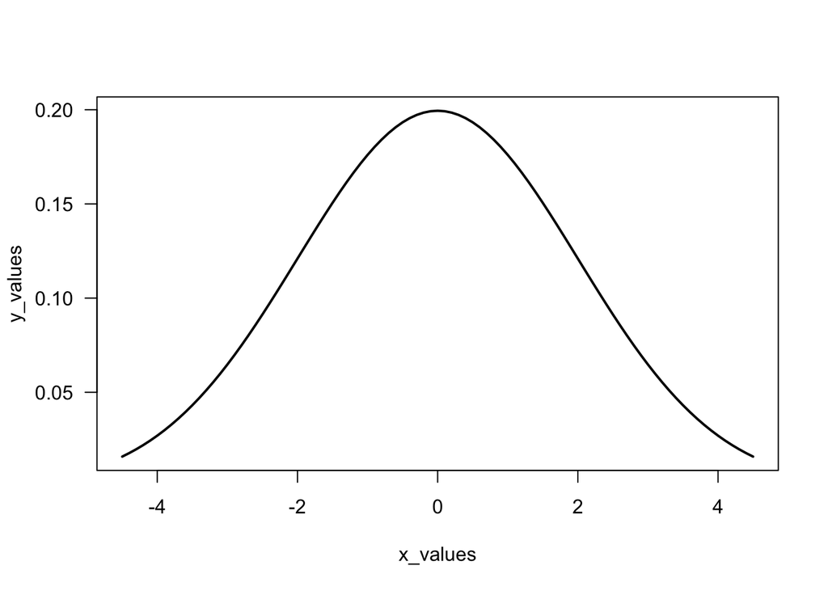

```r
# you should get a plot like this one
x_values <- seq(from = -4.5, to = 4.5, by = 0.1)
y_values <- dnorm(x_values, mean = 0, sd = 2)
plot(x_values, y_values, las = 1, type = "l", lwd = 2)
```

Your turn:

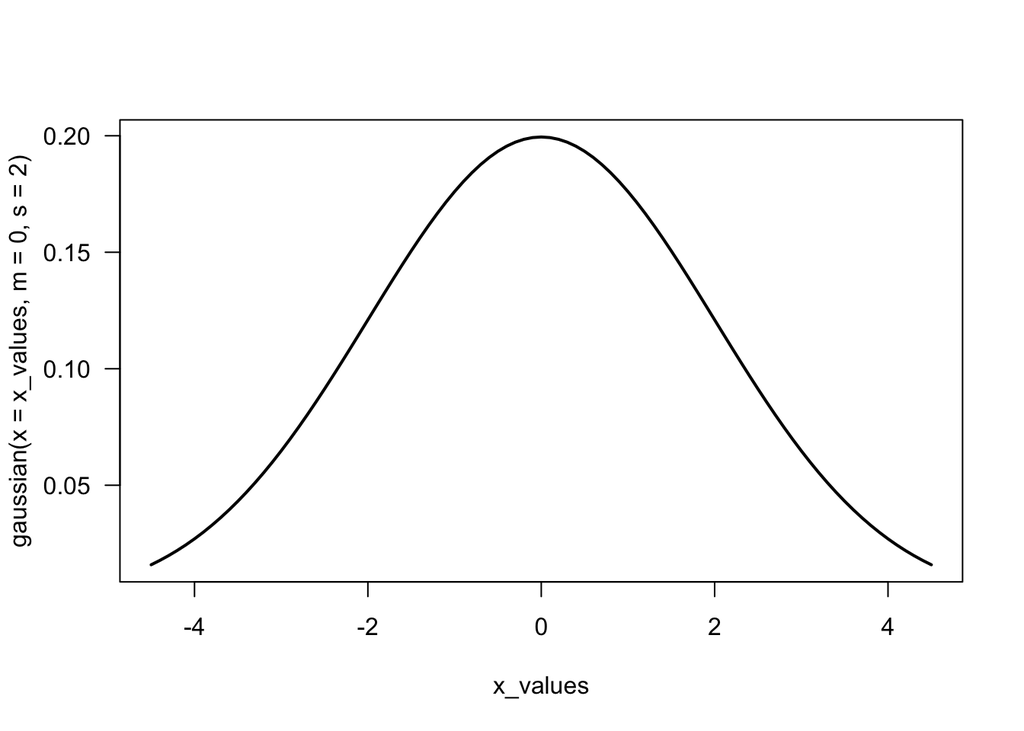

```r
plot(x_values, gaussian(x = x_values, m = 0, s = 2), las = 1, type = "l", lwd = 2)
```